# 5xFAD mouse analysis

## 1. Import Data

We will firstly import the counts data and sample metadata from GEO.

The counts were downloaded as the `GSE140286_FAD_time_series_rnaseq_raw_count.txt.gz` file from the GEO accession GSE140286.

```r
counts <- here("R/Mouse/data/GSE140286_FAD_time_series_rnaseq_raw_count.txt") %>%
  read_tsv
```

The names of the samples are:

```r
sampleNames <- counts[,-c(1)] %>% colnames
sampleNames
```

```
 [1] "SJMMALZ058765_G1" "SJMMALZ058766_G1" "SJMMALZ058768_G1" "SJMMALZ058769_G1" "SJMMALZ058771_G1" "SJMMALZ058772_G1" "SJMMALZ058773_G1" "SJMMALZ058774_G1"
 [9] "SJMMALZ058775_G1" "SJMMALZ058776_G1" "SJMMALZ058778_G1" "SJMMALZ058779_G1" "SJMMALZ058780_G1" "SJMMALZ058781_G1" "SJMMALZ058782_G1"
```

The samples were then retrieved from GEO and converted into a `tibble`.

```r
samples <- getGEO(filename = here::here("R/Mouse/data/GSE140286_series_matrix.txt"), getGPL = FALSE) %>%
  phenoData %>%
  pData %>%
  as_tibble
head(samples)
```

| title | geo_accession | status | submission_date | last_update_date | type | channel_count | source_name_ch1 | organism_ch1 | characteristics_ch1 | characteristics_ch1.1 | characteristics_ch1.2 | characteristics_ch1.3 | molecule_ch1 | extract_protocol_ch1 | extract_protocol_ch1.1 | taxid_ch1 | description | description.1 | data_processing | data_processing.1 | data_processing.2 | data_processing.3 | platform_id | contact_name | contact_email | contact_department | contact_institute | contact_address | contact_city | … |
| --- | --- | --- | --- | --- | --- | --- | --- | --- | --- | --- | --- | --- | --- | --- | --- | --- | --- | --- | --- | --- | --- | --- | --- | --- | --- | --- | --- | --- | --- | --- |
| WT_3mo_1 | GSM4158886 | Public on Dec 04 2019 | Nov 12 2019 | Dec 04 2019 | SRA | 1 | Non transgenic control | Mus musculus | age: 3 months | tissue: Cortex | genotype: control | strain: C57BL/6J | polyA RNA | RNAs were extracted by Trizol (Invitrogen) from about 20 mg aliquots of the same tumor samples for proteomics analyses. | For RNAseq, libraries were generated from ~1 µg total RNA using the Illumina Stranded Total RNA kit with the Human/Mouse/Rat Ribo-Zero Gold ribosomal reduction kit. Libraries were sequenced on an Illu… | 10090 | Total RNA was extracted from cortex 3 months of age. | SJMMALZ058765_G1 | Basecalls performed using CASAVA | fastq files werer mapped by StrongARM, an internal mapping pipeline that performs STAR and bwa mapping. | reads were counted using an internal perl script and converted to FPKM using mm9 | Genome_build: mm9 | GPL17021 | Timothy,Isham,Shaw | gatechatl@gmail.com | Computational Biology | St Jude Children's Research Hospital | 262 Danny Thomas Pl | Memphis | … |
| WT_3mo_2 | GSM4158887 | Public on Dec 04 2019 | Nov 12 2019 | Dec 04 2019 | SRA | 1 | Non transgenic control | Mus musculus | age: 3 months | tissue: Cortex | genotype: control | strain: C57BL/6J | polyA RNA | RNAs were extracted by Trizol (Invitrogen) from about 20 mg aliquots of the same tumor samples for proteomics analyses. | For RNAseq, libraries were generated from ~1 µg total RNA using the Illumina Stranded Total RNA kit with the Human/Mouse/Rat Ribo-Zero Gold ribosomal reduction kit. Libraries were sequenced on an Illu… | 10090 | Total RNA was extracted from cortex 3 months of age. | SJMMALZ058766_G1 | Basecalls performed using CASAVA | fastq files werer mapped by StrongARM, an internal mapping pipeline that performs STAR and bwa mapping. | reads were counted using an internal perl script and converted to FPKM using mm9 | Genome_build: mm9 | GPL17021 | Timothy,Isham,Shaw | gatechatl@gmail.com | Computational Biology | St Jude Children's Research Hospital | 262 Danny Thomas Pl | Memphis | … |
| 5XFAD_3mo_1 | GSM4158888 | Public on Dec 04 2019 | Nov 12 2019 | Dec 04 2019 | SRA | 1 | 5XFAD transgenic mice | Mus musculus | age: 3 months | tissue: Cortex | genotype: amyloid deposition expresses five familial AD (FAD) mutations | strain: C57BL/6J | polyA RNA | RNAs were extracted by Trizol (Invitrogen) from about 20 mg aliquots of the same tumor samples for proteomics analyses. | For RNAseq, libraries were generated from ~1 µg total RNA using the Illumina Stranded Total RNA kit with the Human/Mouse/Rat Ribo-Zero Gold ribosomal reduction kit. Libraries were sequenced on an Illu… | 10090 | Total RNA was extracted from cortex 3 months of age. | SJMMALZ058768_G1 | Basecalls performed using CASAVA | fastq files werer mapped by StrongARM, an internal mapping pipeline that performs STAR and bwa mapping. | reads were counted using an internal perl script and converted to FPKM using mm9 | Genome_build: mm9 | GPL17021 | Timothy,Isham,Shaw | gatechatl@gmail.com | Computational Biology | St Jude Children's Research Hospital | 262 Danny Thomas Pl | Memphis | … |
| 5XFAD_3mo_2 | GSM4158889 | Public on Dec 04 2019 | Nov 12 2019 | Dec 04 2019 | SRA | 1 | 5XFAD transgenic mice | Mus musculus | age: 3 months | tissue: Cortex | genotype: amyloid deposition expresses five familial AD (FAD) mutations | strain: C57BL/6J | polyA RNA | RNAs were extracted by Trizol (Invitrogen) from about 20 mg aliquots of the same tumor samples for proteomics analyses. | For RNAseq, libraries were generated from ~1 µg total RNA using the Illumina Stranded Total RNA kit with the Human/Mouse/Rat Ribo-Zero Gold ribosomal reduction kit. Libraries were sequenced on an Illu… | 10090 | Total RNA was extracted from cortex 3 months of age. | SJMMALZ058769_G1 | Basecalls performed using CASAVA | fastq files werer mapped by StrongARM, an internal mapping pipeline that performs STAR and bwa mapping. | reads were counted using an internal perl script and converted to FPKM using mm9 | Genome_build: mm9 | GPL17021 | Timothy,Isham,Shaw | gatechatl@gmail.com | Computational Biology | St Jude Children's Research Hospital | 262 Danny Thomas Pl | Memphis | … |
| WT_6mo_1 | GSM4158890 | Public on Dec 04 2019 | Nov 12 2019 | Dec 04 2019 | SRA | 1 | Non transgenic control | Mus musculus | age: 6 months | tissue: Cortex | genotype: control | strain: C57BL/6J | polyA RNA | RNAs were extracted by Trizol (Invitrogen) from about 20 mg aliquots of the same tumor samples for proteomics analyses. | For RNAseq, libraries were generated from ~1 µg total RNA using the Illumina Stranded Total RNA kit with the Human/Mouse/Rat Ribo-Zero Gold ribosomal reduction kit. Libraries were sequenced on an Illu… | 10090 | Total RNA was extracted from cortex 6 months of age. | SJMMALZ058771_G1 | Basecalls performed using CASAVA | fastq files werer mapped by StrongARM, an internal mapping pipeline that performs STAR and bwa mapping. | reads were counted using an internal perl script and converted to FPKM using mm9 | Genome_build: mm9 | GPL17021 | Timothy,Isham,Shaw | gatechatl@gmail.com | Computational Biology | St Jude Children's Research Hospital | 262 Danny Thomas Pl | Memphis | … |
| WT_6mo_2 | GSM4158891 | Public on Dec 04 2019 | Nov 12 2019 | Dec 04 2019 | SRA | 1 | Non transgenic control | Mus musculus | age: 6 months | tissue: Cortex | genotype: control | strain: C57BL/6J | polyA RNA | RNAs were extracted by Trizol (Invitrogen) from about 20 mg aliquots of the same tumor samples for proteomics analyses. | For RNAseq, libraries were generated from ~1 µg total RNA using the Illumina Stranded Total RNA kit with the Human/Mouse/Rat Ribo-Zero Gold ribosomal reduction kit. Libraries were sequenced on an Illu… | 10090 | Total RNA was extracted from cortex 6 months of age. | SJMMALZ058772_G1 | Basecalls performed using CASAVA | fastq files werer mapped by StrongARM, an internal mapping pipeline that performs STAR and bwa mapping. | reads were counted using an internal perl script and converted to FPKM using mm9 | Genome_build: mm9 | GPL17021 | Timothy,Isham,Shaw | gatechatl@gmail.com | Computational Biology | St Jude Children's Research Hospital | 262 Danny Thomas Pl | Memphis | … |

```r
colnames(samples)
```

```
 [1] "title"                   "geo_accession"           "status"                  "submission_date"         "last_update_date"        "type"
 [7] "channel_count"           "source_name_ch1"         "organism_ch1"            "characteristics_ch1"     "characteristics_ch1.1"   "characteristics_ch1.2"
[13] "characteristics_ch1.3"   "molecule_ch1"            "extract_protocol_ch1"    "extract_protocol_ch1.1"  "taxid_ch1"               "description"
[19] "description.1"           "data_processing"         "data_processing.1"       "data_processing.2"       "data_processing.3"       "platform_id"
[25] "contact_name"            "contact_email"           "contact_department"      "contact_institute"       "contact_address"         "contact_city"
[31] "contact_state"           "contact_zip/postal_code" "contact_country"         "data_row_count"          "instrument_model"        "library_selection"
[37] "library_source"          "library_strategy"        "relation"                "relation.1"              "supplementary_file_1"    "age:ch1"
[43] "genotype:ch1"            "strain:ch1"              "tissue:ch1"
```

There is a lot of metadata which will be not relevant to our analysis, so let’s keep only the relevant columns corresponding to `age` in months, `genotype`, and `tissue`. The samples table now looks like this:

```r
samples %<>% dplyr::select(description.1,
                          title,
                          starts_with("age"),
                          starts_with("genotype"),
                          starts_with("tissue"),
                          contains("Sample_characteristics_ch1"))  %>%
    dplyr::rename(id = description.1,
                name = title,
                age = `age:ch1`,
                genotype = `genotype:ch1`,
                tissue = `tissue:ch1`) %>%
  dplyr::mutate(age = gsub(x = age,
                           pattern = " months",
                           replacement = ""),
                age = as.numeric(age)) %>%
  dplyr::mutate(genotype = gsub(x = name,
                                pattern = "_(.)*$",
                                replacement = ""),
                genotype = factor(genotype,
                                  levels = c("5XFAD","WT")))
samples
```

| id | name | age | genotype | tissue |
| --- | --- | --- | --- | --- |
| SJMMALZ058765_G1 | WT_3mo_1 | 3 | WT | Cortex |
| SJMMALZ058766_G1 | WT_3mo_2 | 3 | WT | Cortex |
| SJMMALZ058768_G1 | 5XFAD_3mo_1 | 3 | 5XFAD | Cortex |
| SJMMALZ058769_G1 | 5XFAD_3mo_2 | 3 | 5XFAD | Cortex |
| SJMMALZ058771_G1 | WT_6mo_1 | 6 | WT | Cortex |
| SJMMALZ058772_G1 | WT_6mo_2 | 6 | WT | Cortex |
| SJMMALZ058773_G1 | WT_6mo_3 | 6 | WT | Cortex |
| SJMMALZ058774_G1 | 5XFAD_6mo_1 | 6 | 5XFAD | Cortex |
| SJMMALZ058775_G1 | 5XFAD_6mo_2 | 6 | 5XFAD | Cortex |
| SJMMALZ058776_G1 | 5XFAD_6mo_3 | 6 | 5XFAD | Cortex |

[output cut: 5 more lines]

Check the “id” column in `samples` corresponds to the `sampleNames`.

```r
samples$id %in% sampleNames # Are all samples in sample table present in counts samples?
```

```
 [1] TRUE TRUE TRUE TRUE TRUE TRUE TRUE TRUE TRUE TRUE TRUE TRUE TRUE TRUE TRUE
```

```r
samples$id == sampleNames # Is the order the same?
```

```
 [1]  TRUE  TRUE  TRUE  TRUE  TRUE  TRUE  TRUE  TRUE  TRUE  TRUE  TRUE FALSE  TRUE  TRUE FALSE
```

The ordering of samples isn’t the same across the sample table and the counts matrix, so we will re-order the rows in `samples` so that they match the order of `sampleNames` from the `counts` matrix.

```r
samples <- samples %>%
  as.data.frame %>%
  set_rownames(.$id) %>%
  magrittr::extract(sampleNames, )
```

```r
samples
```

```
                               id         name age genotype tissue
SJMMALZ058765_G1 SJMMALZ058765_G1     WT_3mo_1   3       WT Cortex
SJMMALZ058766_G1 SJMMALZ058766_G1     WT_3mo_2   3       WT Cortex
SJMMALZ058768_G1 SJMMALZ058768_G1  5XFAD_3mo_1   3    5XFAD Cortex
SJMMALZ058769_G1 SJMMALZ058769_G1  5XFAD_3mo_2   3    5XFAD Cortex
SJMMALZ058771_G1 SJMMALZ058771_G1     WT_6mo_1   6       WT Cortex
SJMMALZ058772_G1 SJMMALZ058772_G1     WT_6mo_2   6       WT Cortex
SJMMALZ058773_G1 SJMMALZ058773_G1     WT_6mo_3   6       WT Cortex
SJMMALZ058774_G1 SJMMALZ058774_G1  5XFAD_6mo_1   6    5XFAD Cortex
SJMMALZ058775_G1 SJMMALZ058775_G1  5XFAD_6mo_2   6    5XFAD Cortex
SJMMALZ058776_G1 SJMMALZ058776_G1  5XFAD_6mo_3   6    5XFAD Cortex
SJMMALZ058778_G1 SJMMALZ058778_G1    WT_12mo_2  12       WT Cortex
SJMMALZ058779_G1 SJMMALZ058779_G1 5XFAD_12mo_3  12    5XFAD Cortex
SJMMALZ058780_G1 SJMMALZ058780_G1 5XFAD_12mo_1  12    5XFAD Cortex
SJMMALZ058781_G1 SJMMALZ058781_G1 5XFAD_12mo_2  12    5XFAD Cortex
SJMMALZ058782_G1 SJMMALZ058782_G1    WT_12mo_3  12       WT Cortex
```

```r
samples$id == sampleNames # Confirm order matches now
```

```
 [1] TRUE TRUE TRUE TRUE TRUE TRUE TRUE TRUE TRUE TRUE TRUE TRUE TRUE TRUE TRUE
```

```r
#counts <- as.data.frame(counts) %>% rownames_to_column("Gene")
```

```r
counts %>% head
```

| Gene | SJMMALZ058765_G1 | SJMMALZ058766_G1 | SJMMALZ058768_G1 | SJMMALZ058769_G1 | SJMMALZ058771_G1 | SJMMALZ058772_G1 | SJMMALZ058773_G1 | SJMMALZ058774_G1 | SJMMALZ058775_G1 | SJMMALZ058776_G1 | SJMMALZ058778_G1 | SJMMALZ058779_G1 | SJMMALZ058780_G1 | SJMMALZ058781_G1 | SJMMALZ058782_G1 |
| --- | --- | --- | --- | --- | --- | --- | --- | --- | --- | --- | --- | --- | --- | --- | --- |
| ENSMUSG00000039361 | 23145 | 23668 | 27445 | 24838 | 15039 | 20127 | 19087 | 20956 | 25575 | 34572 | 13748 | 32140 | 22482 | 27092 | 14049 |
| ENSMUSG00000039364 | 0 | 0 | 0 | 1 | 0 | 0 | 4 | 0 | 0 | 8 | 1 | 0 | 5 | 0 | 3 |
| ENSMUSG00000068303 | 0 | 3 | 2 | 3 | 0 | 0 | 8 | 4 | 0 | 3 | 9 | 8 | 8 | 1 | 2 |
| ENSMUSG00000001018 | 6664 | 6084 | 8344 | 8552 | 4586 | 6385 | 6128 | 6414 | 7930 | 10261 | 4659 | 10003 | 7572 | 7691 | 4673 |
| ENSMUSG00000068302 | 3 | 4 | 6 | 6 | 1 | 6 | 3 | 6 | 4 | 2 | 0 | 5 | 5 | 6 | 1 |
| ENSMUSG00000061510 | 73 | 11 | 63 | 24 | 15 | 8 | 25 | 31 | 42 | 44 | 11 | 39 | 46 | 49 | 31 |

## 2. Analysis

Like our other DE analyses, we will format the data to do a `limma-voom`-based analysis.

In this analysis, we will perform the comparison mutant (5XFAD) vs WT to:

- identify DE genes (might be able to see some overlap / concordance between this and our zebrafish dataset)
- gene set enrichment analysis with Hallmark / KEGG gene sets
- gene set enrichment analysis with IRE gene sets

### 2.1. DE gene analysis

#### 2.1.1. Gene annotation from `AnnotationHub`

We will retrieve the gene annotation from Ensembl release 94 as follows.

```r
ah <- AnnotationHub()
```

```
snapshotDate(): 2018-10-24
```

```r
# ah %>%
#   subset(grepl("musculus", species)) %>%
#   subset(rdataclass == "EnsDb")
ensDb <- ah[["AH64944"]]
```

```
downloading 0 resources
loading from cache
    '/Users/nhihin//.AnnotationHub/71690'
```

```r
genes <- genes(ensDb)
genes <- as.data.frame(genes)
head(genes)
```

```
                   seqnames   start     end  width strand            gene_id     gene_name         gene_biotype seq_coord_system
ENSMUSG00000102693        1 3073253 3074322   1070      + ENSMUSG00000102693 4933401J01Rik                  TEC       chromosome
ENSMUSG00000064842        1 3102016 3102125    110      + ENSMUSG00000064842       Gm26206                snRNA       chromosome
ENSMUSG00000051951        1 3205901 3671498 465598      - ENSMUSG00000051951          Xkr4       protein_coding       chromosome
ENSMUSG00000102851        1 3252757 3253236    480      + ENSMUSG00000102851       Gm18956 processed_pseudogene       chromosome
ENSMUSG00000103377        1 3365731 3368549   2819      - ENSMUSG00000103377       Gm37180                  TEC       chromosome
ENSMUSG00000104017        1 3375556 3377788   2233      - ENSMUSG00000104017       Gm37363                  TEC       chromosome
                                                                             description      gene_id_version        symbol entrezid
ENSMUSG00000102693        RIKEN cDNA 4933401J01 gene [Source:MGI Symbol;Acc:MGI:1918292] ENSMUSG00000102693.1 4933401J01Rik       NA
ENSMUSG00000064842             predicted gene, 26206 [Source:MGI Symbol;Acc:MGI:5455983] ENSMUSG00000064842.1       Gm26206       NA
ENSMUSG00000051951 X-linked Kx blood group related 4 [Source:MGI Symbol;Acc:MGI:3528744] ENSMUSG00000051951.5          Xkr4   497097
ENSMUSG00000102851             predicted gene, 18956 [Source:MGI Symbol;Acc:MGI:5011141] ENSMUSG00000102851.1       Gm18956       NA
ENSMUSG00000103377             predicted gene, 37180 [Source:MGI Symbol;Acc:MGI:5610408] ENSMUSG00000103377.1       Gm37180       NA
ENSMUSG00000104017             predicted gene, 37363 [Source:MGI Symbol;Acc:MGI:5610591] ENSMUSG00000104017.1       Gm37363       NA
```

We will filter `genes` to only contain those identified in this particular RNA-seq experiment (`Gene` column in the `counts` object).

```r
genes <- genes %>% dplyr::filter(gene_id %in% counts$Gene) %>%
  column_to_rownames("gene_id") %>%
  magrittr::extract(counts$Gene, ) %>%
  mutate(ensembl_gene_id = rownames(.))
head(genes)
```

```
  seqnames     start       end width strand gene_name                       gene_biotype seq_coord_system
1        7  90130213  90213465 83253      +    Picalm                     protein_coding       chromosome
2       11 121053458 121063569 10112      -   Sectm1b                     protein_coding       chromosome
3        6  85152621  85156223  3603      +   Spr-ps1 transcribed_unprocessed_pseudogene       chromosome
4        3  90488026  90491033  3008      -    Snapin                     protein_coding       chromosome
5        6  85423886  85428877  4992      +      Noto                     protein_coding       chromosome
6       14  46829109  46832027  2919      -   Gm10101      bidirectional_promoter_lncRNA       chromosome
                                                                                 description       gene_id_version  symbol entrezid    ensembl_gene_id
1 phosphatidylinositol binding clathrin assembly protein [Source:MGI Symbol;Acc:MGI:2385902] ENSMUSG00000039361.11  Picalm   233489 ENSMUSG00000039361
2                          secreted and transmembrane 1B [Source:MGI Symbol;Acc:MGI:1929083] ENSMUSG00000039364.13 Sectm1b    58210 ENSMUSG00000039364
3                     sepiapterin reductase pseudogene 1 [Source:MGI Symbol;Acc:MGI:1345187]  ENSMUSG00000068303.6 Spr-ps1       NA ENSMUSG00000068303
4                                SNAP-associated protein [Source:MGI Symbol;Acc:MGI:1333745] ENSMUSG00000001018.15  Snapin    20615 ENSMUSG00000001018
5                                     notochord homeobox [Source:MGI Symbol;Acc:MGI:3053002]  ENSMUSG00000068302.8    Noto   384452 ENSMUSG00000068302
6                                   predicted gene 10101 [Source:MGI Symbol;Acc:MGI:3641713]  ENSMUSG00000061510.3 Gm10101       NA ENSMUSG00000061510
```

#### 2.1.2. Setting up DGEList object

The `samples`, `counts` and `genes` will be stored in a DGEList object for the DE analysis using *limma*.

```r
dge <- DGEList(
  counts = counts %>% column_to_rownames("Gene"),
  samples = samples,
  genes = genes,
  remove.zeros = TRUE
) %>%
  calcNormFactors("TMM")
```

```
Removing 8336 rows with all zero counts
```

Preview the DGEList and the normalisation factors calculated:

```r
dge
```

```
An object of class "DGEList"
$counts
                   SJMMALZ058765_G1 SJMMALZ058766_G1 SJMMALZ058768_G1 SJMMALZ058769_G1 SJMMALZ058771_G1 SJMMALZ058772_G1 SJMMALZ058773_G1 SJMMALZ058774_G1 SJMMALZ058775_G1
ENSMUSG00000039361            23145            23668            27445            24838            15039            20127            19087            20956            25575
ENSMUSG00000039364                0                0                0                1                0                0                4                0                0
ENSMUSG00000068303                0                3                2                3                0                0                8                4                0
ENSMUSG00000001018             6664             6084             8344             8552             4586             6385             6128             6414             7930
ENSMUSG00000068302                3                4                6                6                1                6                3                6                4
                   SJMMALZ058776_G1 SJMMALZ058778_G1 SJMMALZ058779_G1 SJMMALZ058780_G1 SJMMALZ058781_G1 SJMMALZ058782_G1
ENSMUSG00000039361            34572            13748            32140            22482            27092            14049
ENSMUSG00000039364                8                1                0                5                0                3
ENSMUSG00000068303                3                9                8                8                1                2
ENSMUSG00000001018            10261             4659            10003             7572             7691             4673
ENSMUSG00000068302                2                0                5                5                6                1
29650 more rows ...

$samples
                 group  lib.size norm.factors               id        name age genotype tissue
SJMMALZ058765_G1     1 167667107    0.9695893 SJMMALZ058765_G1    WT_3mo_1   3       WT Cortex
SJMMALZ058766_G1     1 178870158    0.9575075 SJMMALZ058766_G1    WT_3mo_2   3       WT Cortex
SJMMALZ058768_G1     1 202758202    0.9765652 SJMMALZ058768_G1 5XFAD_3mo_1   3    5XFAD Cortex
SJMMALZ058769_G1     1 212855093    0.9879531 SJMMALZ058769_G1 5XFAD_3mo_2   3    5XFAD Cortex
SJMMALZ058771_G1     1 113775650    0.9721350 SJMMALZ058771_G1    WT_6mo_1   6       WT Cortex
10 more rows ...

$genes
                   seqnames     start       end width strand gene_name                       gene_biotype seq_coord_system
ENSMUSG00000039361        7  90130213  90213465 83253      +    Picalm                     protein_coding       chromosome
ENSMUSG00000039364       11 121053458 121063569 10112      -   Sectm1b                     protein_coding       chromosome
ENSMUSG00000068303        6  85152621  85156223  3603      +   Spr-ps1 transcribed_unprocessed_pseudogene       chromosome
ENSMUSG00000001018        3  90488026  90491033  3008      -    Snapin                     protein_coding       chromosome
ENSMUSG00000068302        6  85423886  85428877  4992      +      Noto                     protein_coding       chromosome
                                                                                                  description       gene_id_version  symbol entrezid    ensembl_gene_id
ENSMUSG00000039361 phosphatidylinositol binding clathrin assembly protein [Source:MGI Symbol;Acc:MGI:2385902] ENSMUSG00000039361.11  Picalm   233489 ENSMUSG00000039361
ENSMUSG00000039364                          secreted and transmembrane 1B [Source:MGI Symbol;Acc:MGI:1929083] ENSMUSG00000039364.13 Sectm1b    58210 ENSMUSG00000039364
ENSMUSG00000068303                     sepiapterin reductase pseudogene 1 [Source:MGI Symbol;Acc:MGI:1345187]  ENSMUSG00000068303.6 Spr-ps1       NA ENSMUSG00000068303
ENSMUSG00000001018                                SNAP-associated protein [Source:MGI Symbol;Acc:MGI:1333745] ENSMUSG00000001018.15  Snapin    20615 ENSMUSG00000001018
ENSMUSG00000068302                                     notochord homeobox [Source:MGI Symbol;Acc:MGI:3053002]  ENSMUSG00000068302.8    Noto   384452 ENSMUSG00000068302
29650 more rows ...
```

```r
dge$samples$norm.factors
```

```
 [1] 0.9695893 0.9575075 0.9765652 0.9879531 0.9721350 0.9835522 0.9905825 1.0068818 1.0827278 1.0393327 0.9739208 1.0491933 1.0116932 1.0403506 0.9672923
```

#### 2.1.3. Data Exploration

##### Principal Component Analysis

We will use PCA to visualise how similar the samples are to each other based on their overall gene expression.

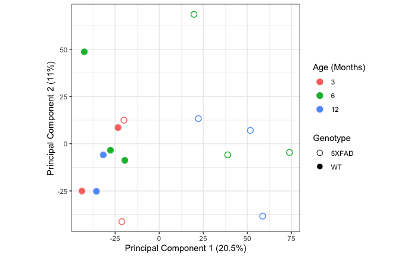

#### 2.1.4. DE Analysis

Create a new variable that groups together the age and genotype:

```r
dge$samples %<>% mutate(group = as.factor(paste0("mth", age, "_", genotype)))
```

Create the design matrix so we can perform comparisons between groups.

```r
design <- model.matrix(~0 + group, data = dge$samples) %>%
  set_colnames(gsub(x = colnames(.), pattern = "group", replacement = ""))
design
```

```
   mth12_5XFAD mth12_WT mth3_5XFAD mth3_WT mth6_5XFAD mth6_WT
1            0        0          0       1          0       0
2            0        0          0       1          0       0
3            0        0          1       0          0       0
4            0        0          1       0          0       0
5            0        0          0       0          0       1
6            0        0          0       0          0       1
7            0        0          0       0          0       1
8            0        0          0       0          1       0
9            0        0          0       0          1       0
10           0        0          0       0          1       0
11           0        1          0       0          0       0
12           1        0          0       0          0       0
13           1        0          0       0          0       0
14           1        0          0       0          0       0
15           0        1          0       0          0       0
attr(,"assign")
[1] 1 1 1 1 1 1
attr(,"contrasts")
attr(,"contrasts")$group
[1] "contr.treatment"
```

Apply the voom method to transform discrete count data into continuous

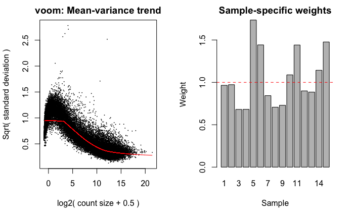

```r
voomData <- voomWithQualityWeights(dge, design = design, plot = TRUE)
```

Define contrasts / comparisons

```r
contrasts <- makeContrasts(
  levels = colnames(design),
  effectOfMutation_3mth = mth3_5XFAD-mth3_WT,
  effectOfMutation_6mth = mth6_5XFAD-mth6_WT,
  effectOfMutation_12mth = mth12_5XFAD-mth12_WT
)
```

Fit the model and see how many overlapping genes there are between comparisons.

```r
fit <- lmFit(voomData, design) %>%
  contrasts.fit(contrasts) %>%
  eBayes(robust = TRUE)
results <- decideTests(fit, p.value = 0.05, adjust.method = "fdr", method = "global")
results %>% summary()
```

[output not shown]

```r
#vennCounts(results)
```

```r
write_fit <- write_fit(fit, results)
write_fit_sig <- write_fit %>% dplyr::filter(Res.effectOfMutation_3mth != 0 |
                                        Res.effectOfMutation_6mth != 0 |
                                        Res.effectOfMutation_12mth != 0)
```

Write out analysis objects

### 2.2. Gene Set Enrichment Analysis

We will be using the workflow in `GSEA_Workflow.Rmd`. The steps specific to the mouse dataset are shown below.

```r
v <- voomData

buildGenesetIndex <- function(x, voomObj = v){
  limma::ids2indices(x, rownames(voomObj))
}

genesetsDir <- here::here("R", "GSEA", "data", "human")
h_mapped_m <- readRDS(file.path(genesetsDir, "ens_h_mapped_m.rds"))
c1_mapped_m <- readRDS(file.path(genesetsDir, "ens_c1_mapped_m.rds"))
c2_mapped_m <- readRDS(file.path(genesetsDir, "ens_c2_mapped_m.rds"))
c3_mapped_m <- readRDS(file.path(genesetsDir, "ens_c3_mapped_m.rds"))
c4_mapped_m <- readRDS(file.path(genesetsDir, "ens_c4_mapped_m.rds"))
c5_mapped_m <- readRDS(file.path(genesetsDir, "ens_c5_mapped_m.rds"))
c6_mapped_m <- readRDS(file.path(genesetsDir, "ens_c6_mapped_m.rds"))
c7_mapped_m <- readRDS(file.path(genesetsDir, "ens_c7_mapped_m.rds"))

# Build indices for the GSEA gene sets
h_idx <- buildGenesetIndex(h_mapped_m)
c1_idx <- buildGenesetIndex(c1_mapped_m)
c2_idx <- buildGenesetIndex(c2_mapped_m)
c3_idx <- buildGenesetIndex(c3_mapped_m)
c4_idx <- buildGenesetIndex(c4_mapped_m)
c5_idx <- buildGenesetIndex(c5_mapped_m)
c6_idx <- buildGenesetIndex(c6_mapped_m)
c7_idx <- buildGenesetIndex(c7_mapped_m)

# Kegg index
kegg_idx <- c2_idx[(names(c2_idx) %>% stringr::str_detect("KEGG"))]

# IRE genes
mouseIreGenes <- readRDS(here::here("R/Mouse/data/mouse_ireSets.rds"))
ireGenes_idx <- buildGenesetIndex(mouseIreGenes)
```

The three GSEA methods used were `fry`, `fgsea`, and `camera`. The `combinedGSEA()` function returns the individual results for each method as well as the combined results (*p*-values combined using Wilkinson’s method and then FDR or bonferroni-adjusted).

```r
source(here("R","GSEA","combinedGSEA.R"))
gseaResults_mouse_kegg <- combinedGSEA(v, kegg_idx, design, contrasts)
gseaResults_mouse_ire <- combinedGSEA(v, ireGenes_idx, design, contrasts)
gseaResults_mouse_h <- combinedGSEA(v, h_idx, design, contrasts)
```

Because `combinedGSEA` takes a while to run, we will save the objects to have a closer look at them later without having to re-run the analysis.

```r
gseaResults_mouse_kegg %>% saveRDS(file.path(dataDir, "gseaResults_mouse_kegg.rds"))
gseaResults_mouse_ire %>% saveRDS(file.path(dataDir, "gseaResults_mouse_ire.rds"))
gseaResults_mouse_h %>% saveRDS(file.path(dataDir, "gseaResults_mouse_h.rds"))
```

#### 2.2.1. Results

Import in the saved R objects:

```r
gseaResults_mouse_kegg <- readRDS(file.path(dataDir, "gseaResults_mouse_kegg.rds"))
gseaResults_mouse_ire <- readRDS(file.path(dataDir, "gseaResults_mouse_ire.rds"))
gseaResults_mouse_h <- readRDS(file.path(dataDir, "gseaResults_mouse_h.rds"))
```

##### Hallmark

The `gseaResults_mouse_h` object contains the results from gene set testing using the Hallmark gene set collection. This collection represents 50 different and non-redundant biological activities and is often a useful starting point to assess the biological relevance of gene expression changes in a particular comparison.

The comparisons we are interested in are:

- Mutant (5xFAD) vs wild-type at **3 months**
- Mutant (5xFAD) vs wild-type at **6 months**
- Mutant (5xFAD) vs wild-type at **12 months**

The tables below show that the **hedgehog signalling** gene set along with immune-related gene sets seem to be the most significantly enriched.

Energy metabolism / heme metabolism are not highly ranked. There are more significant ones in the older age-group comparisons, supporting that the 5xFAD mutation also has an age-dependent effect where accumulated gene expression changes cause more effects at an older age.

```r
gseaResults_mouse_h$combTest$effectOfMutation_3mth
```

| id | Geneset | wilkinsonp | fdr | bonferroni |
| --- | --- | --- | --- | --- |
| effectOfMutation_3mth | HALLMARK_HEDGEHOG_SIGNALING | 6.874889e-08 | 4.124934e-06 | 2.034967e-05 |
| effectOfMutation_3mth | HALLMARK_APICAL_SURFACE | 7.012084e-07 | 3.005179e-05 | 2.061553e-04 |
| effectOfMutation_3mth | HALLMARK_CHOLESTEROL_HOMEOSTASIS | 8.340718e-05 | 3.583189e-04 | 1.987766e-02 |
| effectOfMutation_3mth | HALLMARK_INTERFERON_ALPHA_RESPONSE | 8.456928e-05 | 3.583189e-04 | 1.987766e-02 |
| effectOfMutation_3mth | HALLMARK_ALLOGRAFT_REJECTION | 8.599654e-05 | 3.583189e-04 | 1.987766e-02 |
| effectOfMutation_3mth | HALLMARK_INTERFERON_GAMMA_RESPONSE | 8.599654e-05 | 3.583189e-04 | 1.987766e-02 |
| effectOfMutation_3mth | HALLMARK_UV_RESPONSE_DN | 6.028749e-04 | 1.845536e-03 | 1.223836e-01 |
| effectOfMutation_3mth | HALLMARK_PROTEIN_SECRETION | 6.120302e-04 | 1.854637e-03 | 1.236301e-01 |
| effectOfMutation_3mth | HALLMARK_PI3K_AKT_MTOR_SIGNALING | 9.136939e-04 | 2.635656e-03 | 1.799977e-01 |
| effectOfMutation_3mth | HALLMARK_INFLAMMATORY_RESPONSE | 3.693321e-03 | 9.008101e-03 | 6.574112e-01 |

[output cut: 40 more lines]

```r
gseaResults_mouse_h$combTest$effectOfMutation_6mth
```

| id | Geneset | wilkinsonp | fdr | bonferroni |
| --- | --- | --- | --- | --- |
| effectOfMutation_6mth | HALLMARK_HEDGEHOG_SIGNALING | 7.525493e-13 | 2.257648e-10 | 2.257648e-10 |
| effectOfMutation_6mth | HALLMARK_APICAL_SURFACE | 2.609215e-10 | 2.609215e-08 | 7.775460e-08 |
| effectOfMutation_6mth | HALLMARK_EPITHELIAL_MESENCHYMAL_TRANSITION | 1.704395e-06 | 5.681316e-05 | 4.976833e-04 |
| effectOfMutation_6mth | HALLMARK_TNFA_SIGNALING_VIA_NFKB | 5.451418e-06 | 1.056808e-04 | 1.559105e-03 |
| effectOfMutation_6mth | HALLMARK_CHOLESTEROL_HOMEOSTASIS | 5.636308e-06 | 1.056808e-04 | 1.606348e-03 |
| effectOfMutation_6mth | HALLMARK_ALLOGRAFT_REJECTION | 9.131518e-06 | 1.245207e-04 | 2.547693e-03 |
| effectOfMutation_6mth | HALLMARK_APICAL_JUNCTION | 1.605208e-05 | 1.840571e-04 | 4.430374e-03 |
| effectOfMutation_6mth | HALLMARK_COAGULATION | 2.325447e-05 | 2.314356e-04 | 6.301962e-03 |
| effectOfMutation_6mth | HALLMARK_INFLAMMATORY_RESPONSE | 2.518425e-05 | 2.314356e-04 | 6.799749e-03 |
| effectOfMutation_6mth | HALLMARK_KRAS_SIGNALING_UP | 2.937697e-05 | 2.448081e-04 | 7.784898e-03 |

[output cut: 40 more lines]

```r
gseaResults_mouse_h$combTest$effectOfMutation_12mth
```

| id | Geneset | wilkinsonp | fdr | bonferroni |
| --- | --- | --- | --- | --- |
| effectOfMutation_12mth | HALLMARK_HEDGEHOG_SIGNALING | 1.055936e-11 | 1.583904e-09 | 3.157248e-09 |
| effectOfMutation_12mth | HALLMARK_APICAL_SURFACE | 4.064496e-09 | 3.048372e-07 | 1.207155e-06 |
| effectOfMutation_12mth | HALLMARK_EPITHELIAL_MESENCHYMAL_TRANSITION | 6.676956e-07 | 3.005179e-05 | 1.969702e-04 |
| effectOfMutation_12mth | HALLMARK_TNFA_SIGNALING_VIA_NFKB | 1.018409e-06 | 3.819033e-05 | 2.983938e-04 |
| effectOfMutation_12mth | HALLMARK_APICAL_JUNCTION | 2.123680e-06 | 6.371041e-05 | 6.179910e-04 |
| effectOfMutation_12mth | HALLMARK_CHOLESTEROL_HOMEOSTASIS | 2.697677e-06 | 6.764558e-05 | 7.823263e-04 |
| effectOfMutation_12mth | HALLMARK_KRAS_SIGNALING_DN | 2.705823e-06 | 6.764558e-05 | 7.823263e-04 |
| effectOfMutation_12mth | HALLMARK_COMPLEMENT | 4.480146e-06 | 1.033880e-04 | 1.290282e-03 |
| effectOfMutation_12mth | HALLMARK_IL2_STAT5_SIGNALING | 4.923064e-06 | 1.054942e-04 | 1.412919e-03 |
| effectOfMutation_12mth | HALLMARK_ESTROGEN_RESPONSE_LATE | 6.322959e-06 | 1.106987e-04 | 1.795720e-03 |

[output cut: 40 more lines]

```r
gseaResults_mouse_h$combTest$effectOfAging_12vs3
```

| id | Geneset | wilkinsonp | fdr | bonferroni |
| --- | --- | --- | --- | --- |
| effectOfAging_12vs3 | HALLMARK_OXIDATIVE_PHOSPHORYLATION | 6.716650e-05 | 0.0003583189 | 0.01746329 |
| effectOfAging_12vs3 | HALLMARK_TGF_BETA_SIGNALING | 9.122111e-05 | 0.0003600833 | 0.02052475 |
| effectOfAging_12vs3 | HALLMARK_UV_RESPONSE_DN | 9.562172e-05 | 0.0003708144 | 0.02141927 |
| effectOfAging_12vs3 | HALLMARK_EPITHELIAL_MESENCHYMAL_TRANSITION | 9.835864e-05 | 0.0003708144 | 0.02193398 |
| effectOfAging_12vs3 | HALLMARK_TNFA_SIGNALING_VIA_NFKB | 9.861568e-05 | 0.0003708144 | 0.02193398 |
| effectOfAging_12vs3 | HALLMARK_MITOTIC_SPINDLE | 9.888385e-05 | 0.0003708144 | 0.02193398 |
| effectOfAging_12vs3 | HALLMARK_ANGIOGENESIS | 1.795211e-04 | 0.0006262365 | 0.03859704 |
| effectOfAging_12vs3 | HALLMARK_CHOLESTEROL_HOMEOSTASIS | 3.520166e-04 | 0.0011415864 | 0.07357147 |
| effectOfAging_12vs3 | HALLMARK_ANDROGEN_RESPONSE | 4.675574e-04 | 0.0014922043 | 0.09678437 |
| effectOfAging_12vs3 | HALLMARK_ESTROGEN_RESPONSE_EARLY | 4.933095e-04 | 0.0015578194 | 0.10162175 |

[output cut: 40 more lines]

```r
gseaResults_mouse_h$combTest$effectOfAging_12vs6
```

| id | Geneset | wilkinsonp | fdr | bonferroni |
| --- | --- | --- | --- | --- |
| effectOfAging_12vs6 | HALLMARK_MITOTIC_SPINDLE | 7.787631e-05 | 0.0003583189 | 0.01962407 |
| effectOfAging_12vs6 | HALLMARK_UV_RESPONSE_DN | 7.854611e-05 | 0.0003583189 | 0.01963653 |
| effectOfAging_12vs6 | HALLMARK_OXIDATIVE_PHOSPHORYLATION | 8.223431e-05 | 0.0003583189 | 0.01987766 |
| effectOfAging_12vs6 | HALLMARK_P53_PATHWAY | 3.365998e-03 | 0.0082770451 | 0.60251370 |
| effectOfAging_12vs6 | HALLMARK_DNA_REPAIR | 8.233512e-03 | 0.0184332359 | 1.00000000 |
| effectOfAging_12vs6 | HALLMARK_REACTIVE_OXYGEN_SPECIES_PATHWAY | 1.074289e-02 | 0.0233541144 | 1.00000000 |
| effectOfAging_12vs6 | HALLMARK_UV_RESPONSE_UP | 1.100537e-02 | 0.0237525916 | 1.00000000 |
| effectOfAging_12vs6 | HALLMARK_XENOBIOTIC_METABOLISM | 1.384246e-02 | 0.0284434192 | 1.00000000 |
| effectOfAging_12vs6 | HALLMARK_G2M_CHECKPOINT | 1.487395e-02 | 0.0303549987 | 1.00000000 |
| effectOfAging_12vs6 | HALLMARK_GLYCOLYSIS | 1.774771e-02 | 0.0357336472 | 1.00000000 |

[output cut: 40 more lines]

```r
gseaResults_mouse_h$combTest$effectOfAging_6vs3
```

| id | Geneset | wilkinsonp | fdr | bonferroni |
| --- | --- | --- | --- | --- |
| effectOfAging_6vs3 | HALLMARK_E2F_TARGETS | 7.982996e-05 | 0.0003583189 | 0.01987766 |
| effectOfAging_6vs3 | HALLMARK_ESTROGEN_RESPONSE_LATE | 7.991289e-05 | 0.0003583189 | 0.01987766 |
| effectOfAging_6vs3 | HALLMARK_IL2_STAT5_SIGNALING | 7.994324e-05 | 0.0003583189 | 0.01987766 |
| effectOfAging_6vs3 | HALLMARK_APICAL_JUNCTION | 7.997841e-05 | 0.0003583189 | 0.01987766 |
| effectOfAging_6vs3 | HALLMARK_ESTROGEN_RESPONSE_EARLY | 8.001040e-05 | 0.0003583189 | 0.01987766 |
| effectOfAging_6vs3 | HALLMARK_HYPOXIA | 8.002481e-05 | 0.0003583189 | 0.01987766 |
| effectOfAging_6vs3 | HALLMARK_INFLAMMATORY_RESPONSE | 8.007928e-05 | 0.0003583189 | 0.01987766 |
| effectOfAging_6vs3 | HALLMARK_MYOGENESIS | 8.007928e-05 | 0.0003583189 | 0.01987766 |
| effectOfAging_6vs3 | HALLMARK_TNFA_SIGNALING_VIA_NFKB | 8.007928e-05 | 0.0003583189 | 0.01987766 |
| effectOfAging_6vs3 | HALLMARK_EPITHELIAL_MESENCHYMAL_TRANSITION | 8.014346e-05 | 0.0003583189 | 0.01987766 |

[output cut: 40 more lines]

###### Butterfly Plot

[figure not shown]

##### IRE

The IRE gene sets in general show significant enrichment (Bonferroni-adjusted Wilkinson’s *p*-value < 0.05). This can be seen in the tables below.

```r
gseaResults_mouse_ire$combTest$effectOfMutation_3mth
```

| id | Geneset | wilkinsonp | fdr | bonferroni |
| --- | --- | --- | --- | --- |
| effectOfMutation_3mth | ire3_all | 6.291633e-05 | 0.0002981626 | 0.001384159 |
| effectOfMutation_3mth | ire5_all | 9.015178e-04 | 0.0016643405 | 0.010818213 |
| effectOfMutation_3mth | ire3_hq | 3.859280e-03 | 0.0057889201 | 0.038583012 |
| effectOfMutation_3mth | ire5_hq | 9.605761e-01 | 0.9605760525 | 1.000000000 |

```r
gseaResults_mouse_ire$combTest$effectOfMutation_6mth
```

| id | Geneset | wilkinsonp | fdr | bonferroni |
| --- | --- | --- | --- | --- |
| effectOfMutation_6mth | ire3_all | 0.0001444069 | 0.0003465767 | 0.002166104 |
| effectOfMutation_6mth | ire5_all | 0.0002126868 | 0.0004253735 | 0.002764928 |
| effectOfMutation_6mth | ire3_hq | 0.0081028540 | 0.0114393233 | 0.064822832 |
| effectOfMutation_6mth | ire5_hq | 0.0137511038 | 0.0183348051 | 0.096257727 |

```r
gseaResults_mouse_ire$combTest$effectOfMutation_12mth
```

| id | Geneset | wilkinsonp | fdr | bonferroni |
| --- | --- | --- | --- | --- |
| effectOfMutation_12mth | ire3_all | 4.011711e-05 | 0.0002981626 | 0.0009628105 |
| effectOfMutation_12mth | ire3_hq | 5.404165e-05 | 0.0002981626 | 0.0012429579 |
| effectOfMutation_12mth | ire5_all | 9.148050e-05 | 0.0002981626 | 0.0016466489 |
| effectOfMutation_12mth | ire5_hq | 1.916393e-03 | 0.0032852455 | 0.0210803252 |

```r
gseaResults_mouse_ire$combTest$effectOfAging_12vs3
```

| id | Geneset | wilkinsonp | fdr | bonferroni |
| --- | --- | --- | --- | --- |
| effectOfAging_12vs3 | ire3_hq | 9.938752e-05 | 0.0002981626 | 0.001689588 |
| effectOfAging_12vs3 | ire5_all | 1.175554e-04 | 0.0003134812 | 0.001880887 |
| effectOfAging_12vs3 | ire3_all | 1.632486e-04 | 0.0003561789 | 0.002285481 |
| effectOfAging_12vs3 | ire5_hq | 1.990968e-01 | 0.2171965425 | 0.597290492 |

```r
gseaResults_mouse_ire$combTest$effectOfAging_12vs6
```

| id | Geneset | wilkinsonp | fdr | bonferroni |
| --- | --- | --- | --- | --- |
| effectOfAging_12vs6 | ire3_all | 0.0000721052 | 0.0002981626 | 0.001514209 |
| effectOfAging_12vs6 | ire3_hq | 0.0221893580 | 0.0280286628 | 0.133136148 |
| effectOfAging_12vs6 | ire5_all | 0.0294392113 | 0.0353270535 | 0.147196056 |
| effectOfAging_12vs6 | ire5_hq | 0.8763429808 | 0.9144448495 | 1.000000000 |

```r
gseaResults_mouse_ire$combTest$effectOfAging_6vs3
```

| id | Geneset | wilkinsonp | fdr | bonferroni |
| --- | --- | --- | --- | --- |
| effectOfAging_6vs3 | ire3_all | 7.747359e-05 | 0.0002981626 | 0.001549472 |
| effectOfAging_6vs3 | ire3_hq | 8.027212e-05 | 0.0002981626 | 0.001549472 |
| effectOfAging_6vs3 | ire5_all | 3.858301e-03 | 0.0057889201 | 0.038583012 |
| effectOfAging_6vs3 | ire5_hq | 1.486965e-01 | 0.1699388048 | 0.594785817 |

### 2.4. Differences between IRE gene use in aging vs. 5xFAD

Genes contributing most to IRE enrichment in aging

```r
str(leadingEdges)
```

```
List of 4
 $ ire3_all:List of 6
  ..$ effectOfMutation_3mth : chr [1:856] "ENSMUSG00000060131" "ENSMUSG00000001985" "ENSMUSG00000049409" "ENSMUSG00000004460" ...
  ..$ effectOfMutation_6mth : chr [1:674] "ENSMUSG00000023800" "ENSMUSG00000086040" "ENSMUSG00000033342" "ENSMUSG00000020792" ...
  ..$ effectOfMutation_12mth: chr [1:504] "ENSMUSG00000020932" "ENSMUSG00000073411" "ENSMUSG00000024079" "ENSMUSG00000032122" ...
  ..$ effectOfAging_12vs6   : chr [1:633] "ENSMUSG00000025558" "ENSMUSG00000022797" "ENSMUSG00000029190" "ENSMUSG00000061136" ...
  ..$ effectOfAging_6vs3    : chr [1:519] "ENSMUSG00000004460" "ENSMUSG00000086040" "ENSMUSG00000003814" "ENSMUSG00000013275" ...
  ..$ effectOfAging_12vs3   : chr [1:767] "ENSMUSG00000039286" "ENSMUSG00000004460" "ENSMUSG00000007682" "ENSMUSG00000054404" ...
 $ ire5_all:List of 6
  ..$ effectOfMutation_3mth : chr [1:267] "ENSMUSG00000024642" "ENSMUSG00000060257" "ENSMUSG00000063239" "ENSMUSG00000033960" ...
  ..$ effectOfMutation_6mth : chr [1:226] "ENSMUSG00000020173" "ENSMUSG00000042873" "ENSMUSG00000033960" "ENSMUSG00000071454" ...
  ..$ effectOfMutation_12mth: chr [1:175] "ENSMUSG00000005338" "ENSMUSG00000003352" "ENSMUSG00000032224" "ENSMUSG00000058793" ...
  ..$ effectOfAging_12vs6   : chr [1:166] "ENSMUSG00000039046" "ENSMUSG00000032740" "ENSMUSG00000017485" "ENSMUSG00000024642" ...
  ..$ effectOfAging_6vs3    : chr [1:197] "ENSMUSG00000007617" "ENSMUSG00000063455" "ENSMUSG00000020601" "ENSMUSG00000023336" ...
  ..$ effectOfAging_12vs3   : chr [1:182] "ENSMUSG00000007617" "ENSMUSG00000078671" "ENSMUSG00000033960" "ENSMUSG00000025780" ...
 $ ire3_hq :List of 6
  ..$ effectOfMutation_3mth : chr [1:94] "ENSMUSG00000060131" "ENSMUSG00000049409" "ENSMUSG00000032777" "ENSMUSG00000028803" ...
  ..$ effectOfMutation_6mth : chr [1:46] "ENSMUSG00000038807" "ENSMUSG00000028803" "ENSMUSG00000029436" "ENSMUSG00000042671" ...
  ..$ effectOfMutation_12mth: chr [1:60] "ENSMUSG00000033577" "ENSMUSG00000053158" "ENSMUSG00000022952" "ENSMUSG00000028273" ...
  ..$ effectOfAging_12vs6   : chr [1:66] "ENSMUSG00000025558" "ENSMUSG00000022797" "ENSMUSG00000072501" "ENSMUSG00000063108" ...
  ..$ effectOfAging_6vs3    : chr [1:64] "ENSMUSG00000045287" "ENSMUSG00000022814" "ENSMUSG00000060206" "ENSMUSG00000031684" ...
  ..$ effectOfAging_12vs3   : chr [1:83] "ENSMUSG00000060206" "ENSMUSG00000042284" "ENSMUSG00000028273" "ENSMUSG00000025558" ...
 $ ire5_hq :List of 6
  ..$ effectOfMutation_3mth : chr [1:14] "ENSMUSG00000024059" "ENSMUSG00000061718" "ENSMUSG00000052656" "ENSMUSG00000063455" ...
  ..$ effectOfMutation_6mth : chr [1:18] "ENSMUSG00000025534" "ENSMUSG00000041481" "ENSMUSG00000062382" "ENSMUSG00000050708" ...
  ..$ effectOfMutation_12mth: chr [1:12] "ENSMUSG00000025534" "ENSMUSG00000000708" "ENSMUSG00000024661" "ENSMUSG00000050708" ...
  ..$ effectOfAging_12vs6   : chr [1:6] "ENSMUSG00000025780" "ENSMUSG00000055980" "ENSMUSG00000041992" "ENSMUSG00000000708" ...
  ..$ effectOfAging_6vs3    : chr [1:18] "ENSMUSG00000063455" "ENSMUSG00000075602" "ENSMUSG00000001249" "ENSMUSG00000041481" ...
  ..$ effectOfAging_12vs3   : chr [1:17] "ENSMUSG00000025780" "ENSMUSG00000063455" "ENSMUSG00000057074" "ENSMUSG00000034997" ...
```

These lists of sets can be converted into matrices required for `upSetR`:

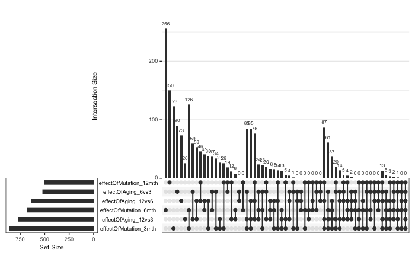

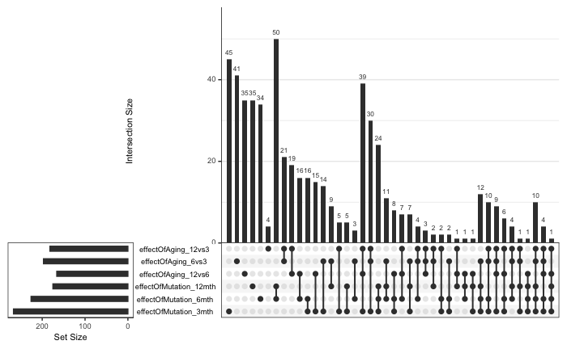

```r
upset_ire5all <- upset(l2m$ire5_all,
      nintersects = NA,
      sets = c("effectOfMutation_3mth",
               "effectOfMutation_6mth",
               "effectOfMutation_12mth",
               "effectOfAging_12vs6",
               "effectOfAging_6vs3",
               "effectOfAging_12vs3"),
      keep.order = TRUE)
upset_ire5all
```

```r
export::graph2ppt(upset_ire5all, here::here("R/Mouse/fig/upset_ire5all"))
```

[output not shown]

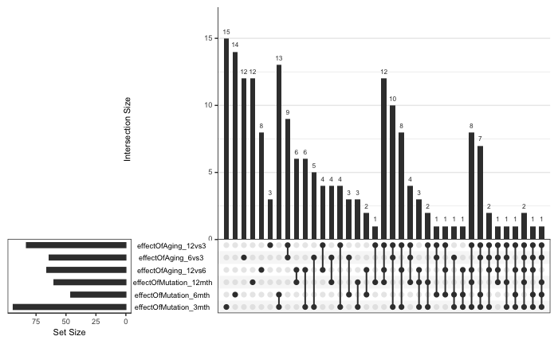

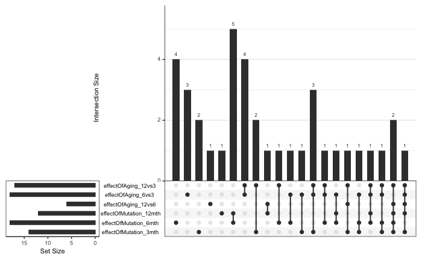